# 2. Regression in R

2023-01-30

Learning objectives

- Produce clear and well-formatted graphs in R
- Generating random numbers - Fit linear regression in R -
- Interpret regression results

# 1 R Graphics

- **High-level plotting functions** create a new plot on the graphics device, possibly with axes, labels, titles and so on.
- **Low-level plotting functions** add more information to an existing plot, such as extra points, lines and labels.

## 1.1 High-level plotting functions

- `pairs(data)` #scatterplot between all variables
- `hist(x)`
- `boxplot(x)` and `boxplot(y~x)`
- `plot (x,y, ...)` #produce a scatterplot according to x and y coordinates
  - `type` #indicates type of plot (points, line, both, …).
  - `axes` #indicates whether axes should be plotted
  - `xlim` `ylim` #specify the limits of the x- and y-axes.
  - `main` `xlab` `ylab` #specify the main and axes titles
  - `plot(density(norm.s)` #plot density

Examples:

1. `hist(data.frame$variable.x)` – plot histrogram of variable X
2. `plot(y~x)` or `plot(data.frame$variable.x, data.frame$varaible.y)` – plot x against y

## 1.2 Low-level plotting functions

- `col` #color
- points(x, y, pch=1, cex=1, col=1)
  - `pch` #plot character
  - `cex` #character expansion (relative size)
- lines(x, y, lty=1, lwd=1)
  - `lty` #line type
  - `lwd` #line width
- Setting for axis annotation, axis and main titles
  - `cex.axis`, `cex.lab`, `cex.main`
  - `font.lab=2` …Bold the axis label

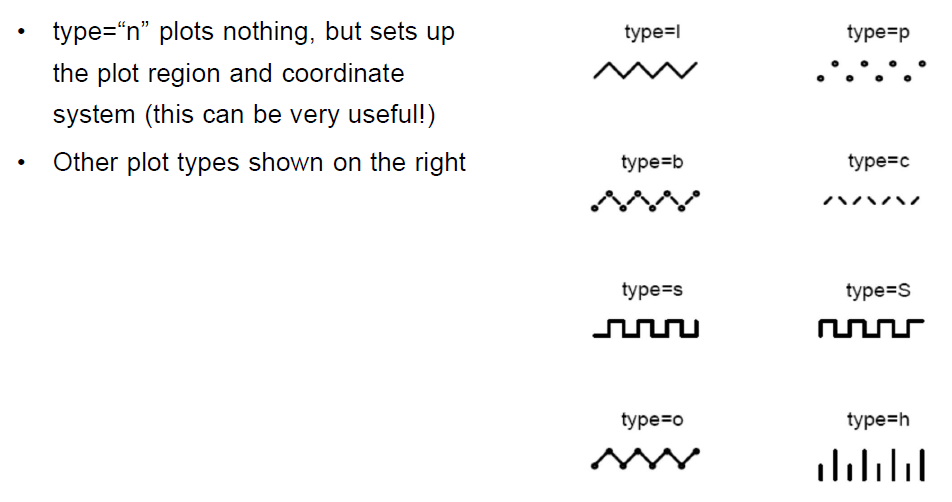

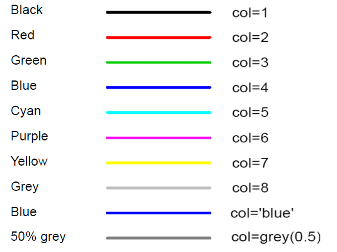

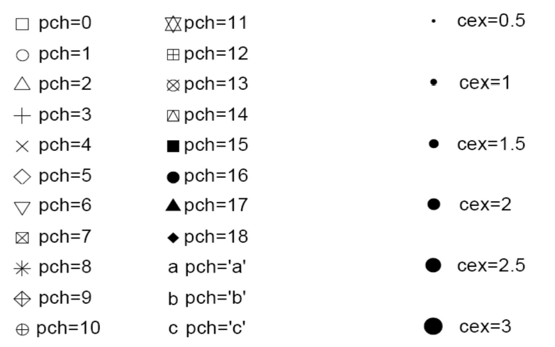

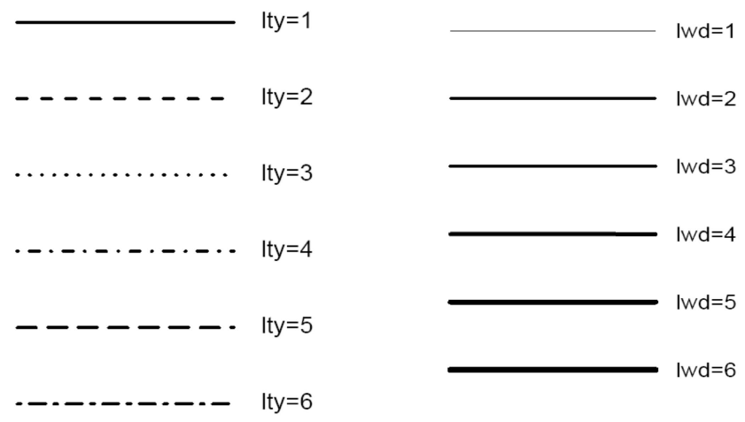

### 1.2.1 Other plotting commands

- `text(x, y, “text”)` … adds “text” at x, y
- `abline(a, b)` … adds line of intercept a, slope b
  - `abline(h=y)` … adds a horizontal line at y
  - `abline(v=x)` … adds a vertical line at x
- `polygon(x, y)` … adds a polygon with corners at each xi, yi (x and y should be vectors)
- `legend(x, y, text)` … adds a legend at x,y
- `title(“title text”)` … adds a title (same effect as “main”)

### 1.2.2 Adding an axis

- `axis(side, pos, at, labels)`
  - `side` =1 for bottom, 2 for left, 3 for top, 4 for right
  - `pos` = positioning of axis
  - `at` = where tick marks should be drawn
  - `labels` = what to write next to each tick mark
  - For a y-axis add the option `las=1` to get horizontal rather than vertical text labels (looks nicer!)
    - `axis(1, pos=11, at=0:5, labels=0:5)`…This adds an x-axis at the horizontal location y=11 with tick marks at x=0,1,…,5 and corresponding labels.

### 1.2.4 Example: MVC data

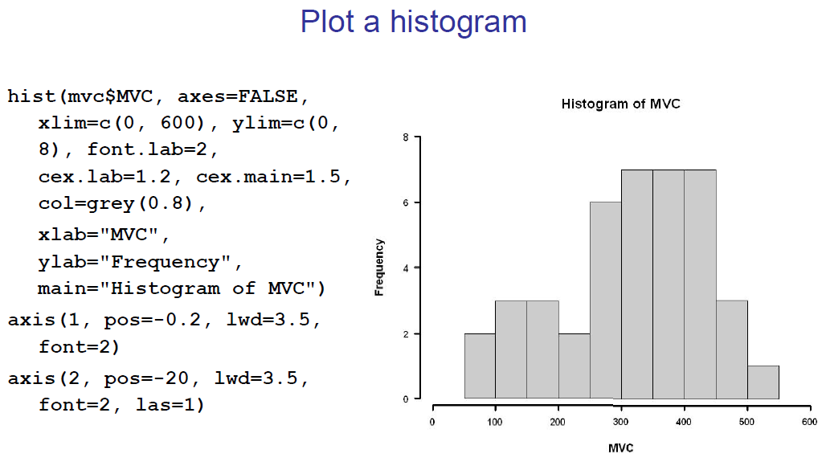

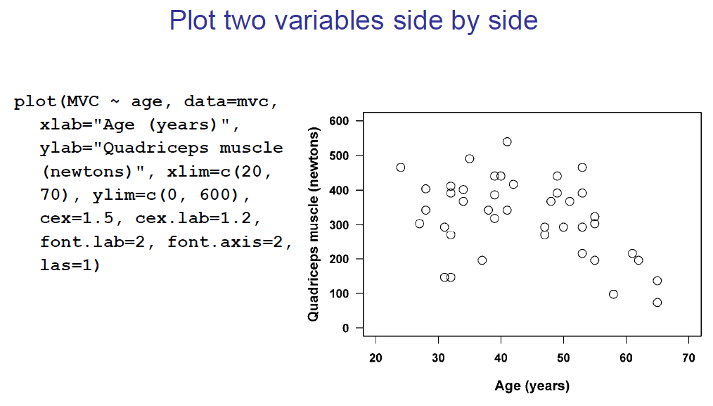

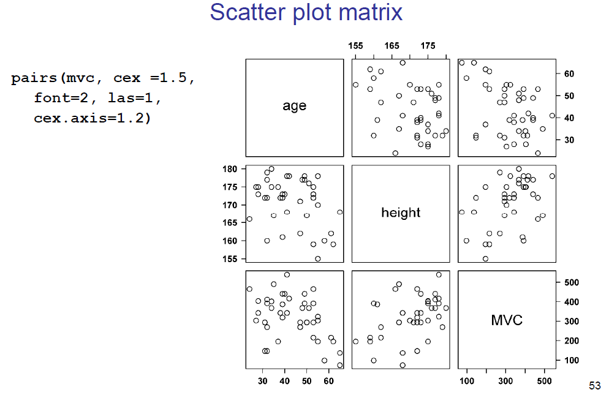

## 1.3 Save graphical output

- `pdf(file, width, height)` … this will start the graphics device driver
  - **file** is the filename and its directory
  - can also save in other format: e.g. bmp, jpeg, png, tiff
- `dev.off()`
  - close the graphics device

  ```r
  ##EXAMPLE
  pdf("figure1.pdf", width=6, height=4) #open a flat sheet
  plot(MVC ~ age, data=mvc) #draw a plot on a flat sheet
  dev.off() #close the file
  ```

# 2 Graphing package: ggplot2 syntax structure

- gg: grammar of graphics
- basic structure: aesthetics and geometric shapes
  - asthetics: x, y position, size/shape/color of elements
  - geometric shapes: points, lines, line segments, bars, text
- [a nice reference for ggplot2](http://www.cookbook-r.com/Graphs/index.html)

## 2.1 Scatter plot

```r
library(ggplot2)

#Example
ggplot(mvc, aes(x=age, y=MVC)) + geom_point() + xlab("Age(years)") +
  ylab("Quadriceps muscle (newtons)")

#Or in separate steps
p <- ggplot(mvc, aes(x=age, y=MVC))
p + geom_point() + xlab("Age (years)") + ylab("Quadriceps muscle (newtons)")

#Add a loess smoothed fit curve with confidence region
ggplot(mvc, aes(age, MVC)) + xlab("Age (years)") +
  ylab("Quadriceps muscle (newtons)") + geom_point() +
stat_smooth(method=loess)

#Fill colour
ggplot(mvc, aes(x=age, y=MVC, fill=height)) + geom_point(shape=21, size=2) +
  scale_fill_gradient(low='blue', high='red')
```

## 2.2 Histogram

```r
#boundary specifies the boundary between two bins, binwidth specifies the width of bins
ggplot(mvc, aes(MVC)) + geom_histogram(binwidth=50, boundary=50, col="black",
                                       fill="blue", alpha=0.3) + ylim(c(0,8))

ggplot(mvc, aes(MVC)) + geom_histogram(binwidth=50, col="black", fill="blue",
                                       alpha=0.3) + ylim(c(0,8))

unif.s<-runif(1000,min=1,max=3)
ggplot() + geom_histogram(aes(x=unif.s, y=..density..), binwidth=0.1,
                          boundary=1, col="black", fill="white") +
ggtitle('Distribution of 1000 uniform samples') + ylim(c(0,0.8))
```

## 2.3 Bar graph

1. `stat_"bin"` …The *count* of cases for each group
2. `stat_"identity"`…The *value* of a column in the data set
- `geom_bar` …Basic bar graph
  - `fill=variable.x`…Map variable x to different fill colors
  - `colour=black`…Add a black outline
  - Example: `ggplot(data=dat, aes(x=time, y=total_bill, fill=time)) +` `geom_bar(colour="black", stat="identity") + guides(fill=FALSE)`
- `geom_line`…Basic line graph
  - `group=1`…All points should be grouped so all points are connected
  - `geom_point()`…Add points
  - Example: `ggplot(data=dat, aes(x=time, y=total_bill, group=1)) +` `geom_line(colour="red", linetype="dashed", size=1.5) +` `geom_point(colour="red", size=4, shape=21, fill="white")`

# 3 Generating random numbers

Draw random samples from discrete / continuous probability distributions e.g. Uniform distribution, simulate what will happen in 10 households in disease outbreak

## 3.1 Uniform Distribution

- `runif(n, min, max)`…Random number with uniform distribution
  - **n** is the number of samples
  - **min / max** are the lower and upper limits of the uniform distribution
- Useful for simulation of random process

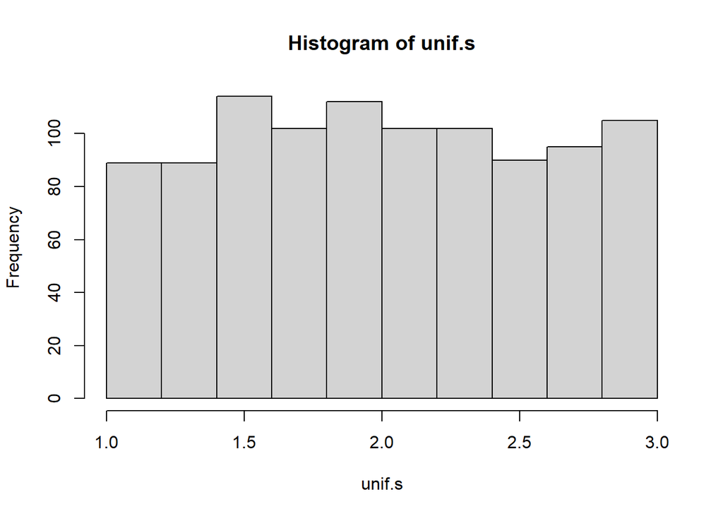

  ```r
  unif.s<-runif(1000,min=1,max=3)
  hist(unif.s) #It's even/uniform distribution
  ```

## 3.2 Binomial distribution

- `rbinom(n, size, prob)`
  - **n** is the number of samples
  - **size** is the number of trials
  - **prob** is the probability of success for each trial

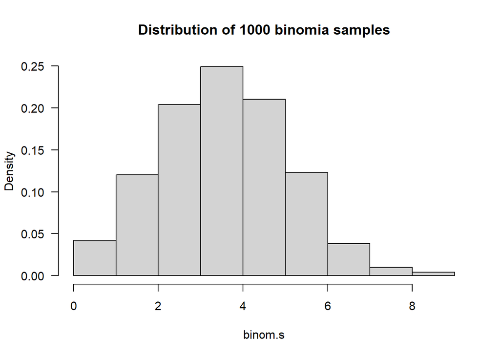

  ```r
  binom.s <- rbinom(1000, size=10, prob=0.4)
  hist(binom.s, main="Distribution of 1000 binomia samples", freq=F, las=1) #expect the mean to be 4
  ```

  ```r
  #rbinom(10, 1,.5)
  #[1] 1 0 1 1 1 0 0 0 0 1
  ```

## 3.3 Normal distribution

- `rnorm(n, mean, sd)`
  - **n** is the number of samples
  - **mean** is the mean / vector of means
  - **sd** is the standard deviation / vector of standard deviations

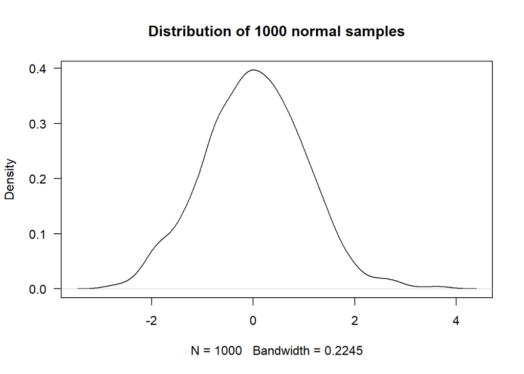

  ```r
  norm.s <- rnorm(1000, mean=0, sd=1)
  plot(density(norm.s), main="Distribution of 1000 normal samples", las=1)
  ```

## 3.4 Random sample

- `sample(x, size, replace, prob)`
  - **x** is a vector from which samples are drawn
  - **size** is the number of samples to be drawn
  - **replace** indicates if the samples are drawn with replacement
  - **prob** specify the probability of selecting each x

  ```r
  sample(seq(1,50), 10, replace=F)
  sample(1:5,20,replace=T,prob=c(0.1,0.35,0.1,0.35,0.1))
  ```

  ```
  ##  [1] 29 11 37 24 36 21 39  8 28 31
  ##  [1] 2 1 3 5 2 4 2 2 2 1 4 2 2 2 2 1 4 2 4 2
  ```

## 3.5 Specify “seed” for randomization

- Seed is an integer which specifies the state of random number generator
- Ensure the result change due to change of script but not random number

  ```r
  set.seed(111)
  runif(3)
  ```

  ```
  ## [1] 0.5929813 0.7264811 0.3704220
  ```

  ```r
  set.seed(111)
  runif(3)
  ```

  ```
  ## [1] 0.5929813 0.7264811 0.3704220
  ```

# 4 Linear regression in R

- If Y is the response variable and X is the explanatory variable, then a simple linear regression states that $Y = α + βX + ε$
  - **ε is distributed N(0, σ2)**, so that $Y \sim\ {\sf Norm}(α + βX, σ^{2})$
- When there is more than one explanatory variable, i.e. more than one X, then the linear regression is not “simple”, but “multiple”.
  - Now $Y \sim\ {\sf Norm} (α + β_{1}X_{1} + β_{2}X_{2} + … +β_{k}X_{k}, σ^{2})$
- Can also include interactions, i.e. terms where two or more of the explanatory variables are multiplied together, and higher-order powers of the variables, e.g. X<sub>1</sub><sup>2</sup>, X<sub>1</sub>X<sub>2</sub>

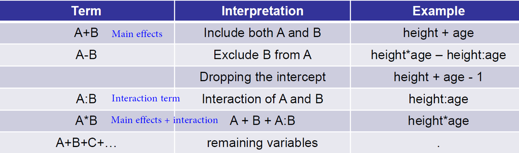

- `lm(formula, data, subset, weights, na.action…)`
  - **formula** is written as y~x+z
  - **data** indicates the data frame to be used
  - **subset** indicates that only some of the data should be used, e.g. subset=(gender==“M”) #Only fit regression model in male; when gender equals to male, we fit the model
  - **weights** weights the observations
  - **na.action** describes what to do with missing data. The default is na.omit (listwise deletion) #default is removing missing data from analysis

  ```r
  mvc <- read.csv("Folder/mvc.CSV")
  ##Fit linear regression model
  #summary(lm(MVC ~ height + age, data=mvc))

  #Or in separate steps:
  mvc.lm <- lm(MVC ~ height + age, data=mvc)
  mvc.lm #The estimated regression equation is: MVC = -465.63 + 5.40 × height – 3.08 × age
  summary(mvc.lm) #Provide more info like sd, p , r-square

  ##Extract result
  mvc.lm$coef #Extract coefficient
  summary(mvc.lm)$coef[2,] #Call out specific numbers to get more accurate result

  ##tell u what are stored in regression output
  names(mvc.lm)
  ```

  ```
  ##
  ## Call:
  ## lm(formula = MVC ~ height + age, data = mvc)
  ##
  ## Coefficients:
  ## (Intercept)       height          age
  ##    -465.626        5.398       -3.075
  ##
  ##
  ## Call:
  ## lm(formula = MVC ~ height + age, data = mvc)
  ##
  ## Residuals:
  ##      Min       1Q   Median       3Q      Max
  ## -220.523  -33.483    5.665   50.917  170.841
  ##
  ## Coefficients:
  ##             Estimate Std. Error t value Pr(>|t|)
  ## (Intercept) -465.626    460.333  -1.011   0.3182
  ## height         5.398      2.545   2.121   0.0405 *
  ## age           -3.075      1.467  -2.096   0.0428 *
  ## ---
  ## Signif. codes:  0 '***' 0.001 '**' 0.01 '*' 0.05 '.' 0.1 ' ' 1
  ##
  ## Residual standard error: 98.92 on 38 degrees of freedom
  ## Multiple R-squared:  0.2612, Adjusted R-squared:  0.2224
  ## F-statistic: 6.719 on 2 and 38 DF,  p-value: 0.003173
  ##
  ## (Intercept)      height         age
  ## -465.626228    5.398182   -3.075405
  ##   Estimate Std. Error    t value   Pr(>|t|)
  ## 5.39818179 2.54502458 2.12107256 0.04049822
  ##  [1] "coefficients"  "residuals"     "effects"       "rank"
  ##  [5] "fitted.values" "assign"        "qr"            "df.residual"
  ##  [9] "xlevels"       "call"          "terms"         "model"
  ```

## 4.1 Convert numeric to factor (categorizing)

  ```r
  x = 1:8
  #Categorize x
  cut(x,c(1,3,6,8)) #1 is not categorized
  cut(x,c(0,3,5,8)) #1 is categorized
  cut(x,c(1,3,5,8), include.lowest=TRUE) #1 is categorized

  #Label the groups
  x <- cut(x,c(1,3,5,8), label=c('low','med','high'), include.lowest=TRUE)

  #Change ref group or oder
  relevel(x, ref='med')
  factor(x, c('high','med','low'))
  ```

  ```
  ## [1] <NA>  (1,3] (1,3] (3,6] (3,6] (3,6] (6,8] (6,8]
  ## Levels: (1,3] (3,6] (6,8]
  ## [1] (0,3] (0,3] (0,3] (3,5] (3,5] (5,8] (5,8] (5,8]
  ## Levels: (0,3] (3,5] (5,8]
  ## [1] [1,3] [1,3] [1,3] (3,5] (3,5] (5,8] (5,8] (5,8]
  ## Levels: [1,3] (3,5] (5,8]
  ## [1] low  low  low  med  med  high high high
  ## Levels: med low high
  ## [1] low  low  low  med  med  high high high
  ## Levels: high med low
  ```

## 4.2 Confidence intervals for the estimated coefficients

- The two-sided 100(1-α)% confidence interval (CI) of an estimated coefficient β is given by $β ± t(1-\frac{α}{2}, n-k) × s_{β}$
  - where t(1-α/2, n-k) is the critical value of the student’s distribution with degree of freedom n-k
    - for α = 0.05, t(0.975, n-k) → z(0.975) = 1.96 when n is large (t distribution close to standard normal distribution when df is large)
  - **k** is the number of parameters in the model including the intercept
  - **s<sub>β</sub>** is the standard error of the estimated coefficient
  - In R, `confint()`: profile likelihood CI, `confint.default()`: Wald CI
    - 2 different theories
      - Profile liklihood CI consider all different parameters
      - Wald: consistent with the p-values in the regression summary table

```r
#Obtain 95%CI
confint(mvc.lm)

#Alternatively (not explained in lecture)
mvc.out <- summary(mvc.lm)
mvc.out
mvc.out$coef[,"Estimate"] %o% c(1,1) + mvc.out$coef[,"Std.Error"] %o% qt(c(0.025,0.975), mvc.out$df[2])
```

## 4.3 Compare model with AIC

`AIC(model1,model2)` …model with lower AIC is better  
Need a large difference (2/4) to accept more complicated model, otherwise use parsimonious model.

## 4.4 Stepwise selection for model

`stepAIC(model, direction)`

- Stepwise selection according to AIC.
- **both** = perform both backward and forward model selection
  - Example: For the model in tutorial 1 with predictors age, height and height2, height is removed coz results in lower AIC on statistcal means

## 4.5 Fit new data to the model

```r
#define new observation
new <- data.frame(age=50, height=170)

#use fitted model to predict the response value for the new observation
predict(lm.mvc4, new, interval = "prediction") #generate prediction interval
```

# 5 Check normality for a set of data

`shapiro.test(data)` …when p-value <0.05, we reject normal distribution

# 6 IF and FOR statement

- `if (condition) statement1 else statement2`
  - **condition** is evaluated
  - **statement1** will be executed if the condition is TRUE
  - else, **statement2** will be executed
  - (grouped statement is enclosed within braces {})

  ```r
  x <- 5
  if (x > 0) print ("x is non-negative!") else print ("x is negative")
  ```

  ```
  ## [1] "x is non-negative!"
  ```

- `for (variable in sequence) statement`
  - **variable** is the loop variable
  - **sequence** is the vector of values for variable within the loop

  ```r
  x <- 0
  for (i in 1:10){
  x <- x + i
  }
  x
  ```

  ```
  ## [1] 55
  ```

  ```r
  sum(1:10)
  ```

  ```
  ## [1] 55
  ```